# Tarea 1: Repaso de R

Gabriela Chavez

### Ejercicio 2.2

```r
install.packages("devtools")
install.packages("tidyverse")
install.packages("demodelr")
install.packages("ggplot2")
library(devtools)
library(tidyverse)
library(demodelr)
library(ggplot2)
```

### Ejercicio 2.3 What are the variables listed in the dataset phosphorous in the demodelr library? (Hint: try the command ?phosphorous.)

- Algae –> Contenido de fosforo en la comida de alga (%)
- Daphnia –> Contenido de fosforo en Daphnia (%)

### Ejercicio 2.4 Make a scatterplot of the dataset phosphourous in the demodelr library.

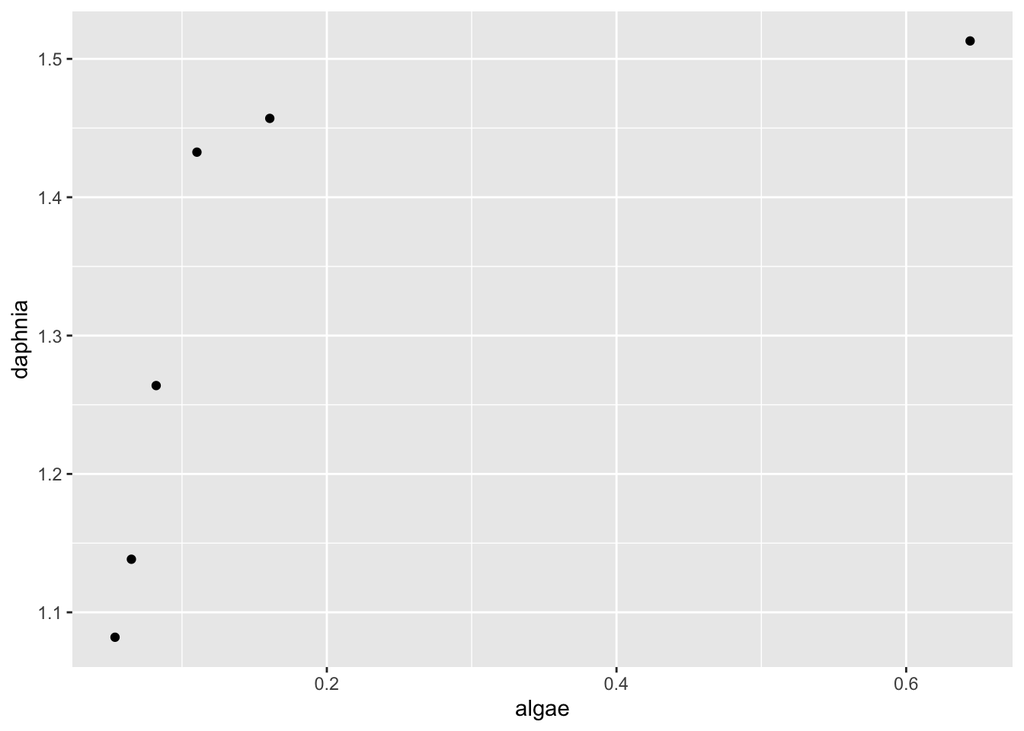

```r
library(demodelr)
library(ggplot2)

 ggplot(phosphorous, aes(algae, daphnia)) +
  geom_point()
```

### Ejercicio 2.5 Cambio Figura 2.3 que la línea es azul y el tamaño es de 4 mm

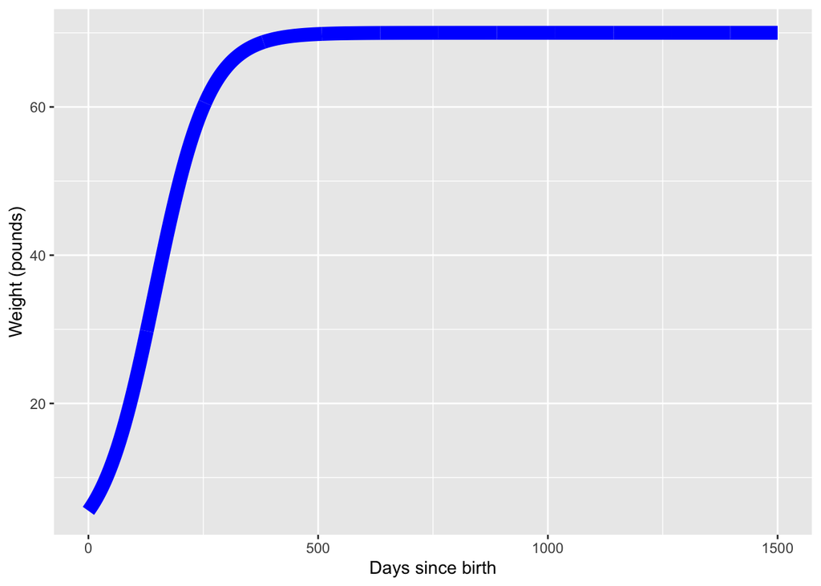

```r
library(tidyr)
# Choose spacing that is "smooth enough"
days <- seq(from = 0, to = 1500, by = 1)
weight <- 70 / (1 + exp(2.46 - 0.017 * days))

wilson_model <- tibble(
  days = days,
  weight = weight
)

ggplot(data = wilson_model) +
  geom_line(aes(x = days, y = weight), color="blue", size=4) +
  labs(
    x = "Days since birth",
    y = "Weight (pounds)"
  )
```

### Ejercicio 2.6 Cambiar el color de los puntos enFigura 2.2 a un color hexadecimal o un color nombrado de su elección.

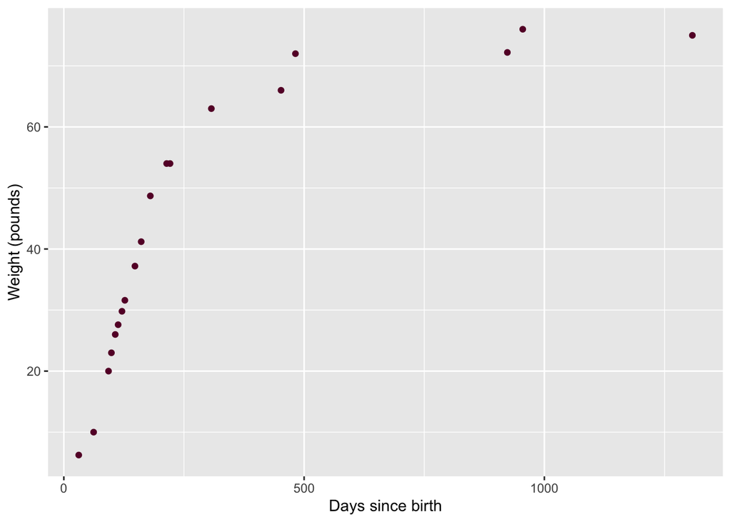

```r
ggplot(data = wilson) +
  geom_point(aes(x = days, y = weight), color = "#660033") +

  labs(
    x = "Days since birth",
    y = "Weight (pounds)"
  )
```

### Ejercicio 2.7 Para este ejercicio harás algunas trazas:

## Definir secuencia llamada x que vaya de -12 a 12 con un espaciado de 0.05

```r
x <- seq (from = -12, to = 12, by= 0.05)
x
```

```
##   [1] -12.00 -11.95 -11.90 -11.85 -11.80 -11.75 -11.70 -11.65 -11.60 -11.55
##  [11] -11.50 -11.45 -11.40 -11.35 -11.30 -11.25 -11.20 -11.15 -11.10 -11.05
##  [21] -11.00 -10.95 -10.90 -10.85 -10.80 -10.75 -10.70 -10.65 -10.60 -10.55
##  [31] -10.50 -10.45 -10.40 -10.35 -10.30 -10.25 -10.20 -10.15 -10.10 -10.05
##  [41] -10.00  -9.95  -9.90  -9.85  -9.80  -9.75  -9.70  -9.65  -9.60  -9.55
##  [51]  -9.50  -9.45  -9.40  -9.35  -9.30  -9.25  -9.20  -9.15  -9.10  -9.05
##  [61]  -9.00  -8.95  -8.90  -8.85  -8.80  -8.75  -8.70  -8.65  -8.60  -8.55
##  [71]  -8.50  -8.45  -8.40  -8.35  -8.30  -8.25  -8.20  -8.15  -8.10  -8.05
##  [81]  -8.00  -7.95  -7.90  -7.85  -7.80  -7.75  -7.70  -7.65  -7.60  -7.55
##  [91]  -7.50  -7.45  -7.40  -7.35  -7.30  -7.25  -7.20  -7.15  -7.10  -7.05
## [101]  -7.00  -6.95  -6.90  -6.85  -6.80  -6.75  -6.70  -6.65  -6.60  -6.55
## [111]  -6.50  -6.45  -6.40  -6.35  -6.30  -6.25  -6.20  -6.15  -6.10  -6.05
## [121]  -6.00  -5.95  -5.90  -5.85  -5.80  -5.75  -5.70  -5.65  -5.60  -5.55
## [131]  -5.50  -5.45  -5.40  -5.35  -5.30  -5.25  -5.20  -5.15  -5.10  -5.05
## [141]  -5.00  -4.95  -4.90  -4.85  -4.80  -4.75  -4.70  -4.65  -4.60  -4.55
```

[output cut: 34 more lines]

## Definir la variable y tal que y= sin (x).

```r
y <- sin(x)
y
```

```
##   [1]  0.536572918  0.578077461  0.618137112  0.656651742  0.693525085
##   [6]  0.728664976  0.761983584  0.793397630  0.822828595  0.850202917
##  [11]  0.875452175  0.898513258  0.919328526  0.937845951  0.954019250
##  [16]  0.967807998  0.979177729  0.988100026  0.994552588  0.998519286
##  [21]  0.999990207  0.998961672  0.995436253  0.989422762  0.980936230
##  [26]  0.969997868  0.956635016  0.940881075  0.922775422  0.902363310
##  [31]  0.879695760  0.854829429  0.827826469  0.798754374  0.767685810
##  [36]  0.734698430  0.699874688  0.663301623  0.625070649  0.585277324
##  [41]  0.544021111  0.501405128  0.457535894  0.412523058  0.366479129
##  [46]  0.319519194  0.271760626  0.223322799  0.174326781  0.124895037
##  [51]  0.075151120  0.025219365 -0.024775425 -0.074708290 -0.124454424
##  [56] -0.173889485 -0.222889914 -0.271333234 -0.319098362 -0.366065911
##  [61] -0.412118485 -0.457140978 -0.501020856 -0.543648444 -0.584917193
##  [66] -0.624723954 -0.662969230 -0.699557429 -0.734397098 -0.767401157
##  [71] -0.798487113 -0.827577266 -0.854598908 -0.879484498 -0.902171834
```

[output cut: 82 more lines]

## Haz un gráfico de dispersión para graficar. Configura los puntos para que sean rojos.

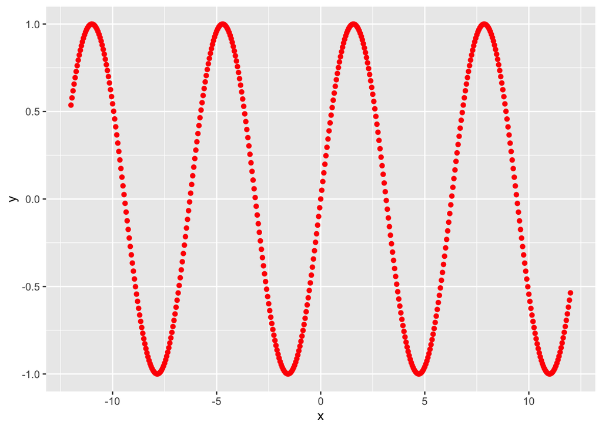

```r
dispers <- tibble(
  x = x,
  y = y
  )

ggplot(dispers)+
  geom_point(aes(x,y), color="red")
```

## Haz un gráfico de líneas para graficar. Etiqueta el eje x con el título de tu libro favorito. Etiqueta el eje y con tu comida favorita para comer.

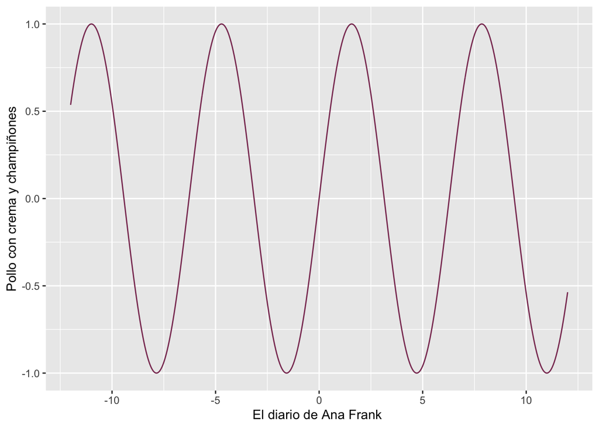

```r
ggplot(dispers)+
  geom_line(aes(x,y), color="hotpink4")+
  labs(
    x = "El diario de Ana Frank ",
    y = "Pollo con crema y champiñones"
  )
```

### Ejercicio 2.10 Investigar algunas funciones.

- Explica con tus propias palabras:
- runif (1,100,1000): Esta función lo que hace es dar 1 número entre el 100 y 1000 aleatoriamente.
- ceiling(): Lo que hace esta función es permitir el redondeo de cifras al número más cercano, por ejemplo si se tiene calificaciones con decimales redondearlas